# Practical Machine Learning - Assignment write-up

## Data loading and assessment

I loaded the data and partitioned into training and validation sets. I used a partition of 0.6 for training:

```r
dat <- read.csv(file="pml-training.csv", header=T, na.strings=c("NA", ""))
dim(dat)
```

```
## [1] 19622   160
```

```r
library(caret)
set.seed(123)
part <- createDataPartition(y=dat$classe, p=0.6, list=F)
training <- dat[part, ]
validation <- dat[-part, ]
dim(training)
```

```
## [1] 11776   160
```

```r
table(training$classe)
```

```
##
##    A    B    C    D    E
## 3348 2279 2054 1930 2165
```

The summary statistics of the training data set (not shown for the sake of space) indicates the presence of predictor columns with a high number of NAs. I subset the training dataset to columns that contain no ‘NA’ values:

```r
##remove all columns that contain any number of 'NA's
training <- training[ ,apply(training, 2, function(x) sum(is.na(x)) == 0)]
dim(training)
```

```
## [1] 11776    60
```

The first 7 columns of the data frame contain irrelevant predictors, so I removed them from the training data frame for ease of handling:

```r
head(colnames(training), n=10)
```

```
##  [1] "X"                    "user_name"            "raw_timestamp_part_1"
##  [4] "raw_timestamp_part_2" "cvtd_timestamp"       "new_window"
##  [7] "num_window"           "roll_belt"            "pitch_belt"
## [10] "yaw_belt"
```

```r
## remove the first 7 columns
training <- training[ ,8:ncol(training)]
dim(training)
```

```
## [1] 11776    53
```

I created a matrix to assess correlation between predictors:

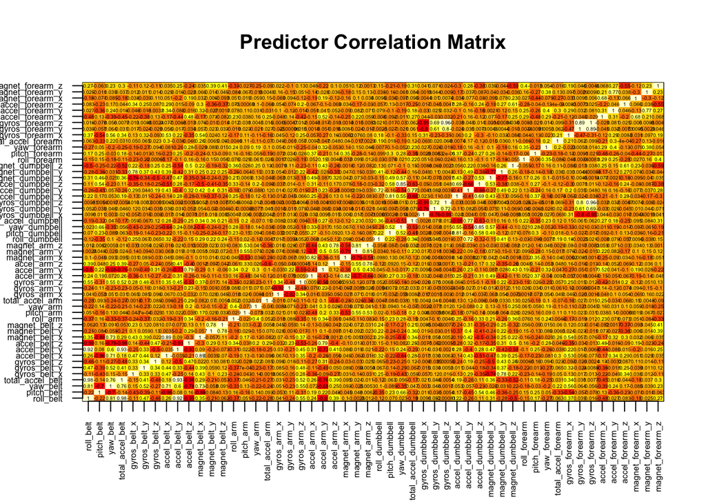

```r
## create a matrix with pair-wise correlations of columns, leaving out the classifier column
mat <- cor(training[ ,1:ncol(training)-1])
## plot matrix with 'image' function
image(1:ncol(mat), 1:ncol(mat), mat, xaxt="n", xlab="", yaxt="n", ylab="", main="Predictor Correlation Matrix")
for(i in 1:ncol(mat)) {
  for(j in 1:nrow(mat)) {
    text(i,j,labels=format(mat[i,j], digits=2), cex=0.3)
  }
}
axis(side=1, at=seq(1,ncol(mat),by=1), labels=colnames(mat), cex.axis=0.5, las=2)
axis(side=2, at=seq(1, nrow(mat), by=1), labels=rownames(mat), cex.axis=0.5, las=2)
```

A number of predictors are highly correlated. I decided to remove these from the training data:

```r
## count the number of descriptors with a very high (>0.9) correlation
sum(abs(mat[upper.tri(mat)]) > 0.8)
```

```
## [1] 19
```

```r
## identify pairs of descriptor columns with high correlation
hi.cor <- findCorrelation(mat, cutoff = 0.8)
## remove highly correlated descriptors
training <- training[, -hi.cor]
dim(training)
```

```
## [1] 11776    41
```

## Model building

I decided to build a model based on random forest analysis, a suitable algorithm for large numbers of predictors:

```r
set.seed(111)
mod.rf <- train(classe ~ ., data=training, method="rf", trControl=trainControl(method="cv"))
## final model:
mod.rf$finalModel
```

```
##
## Call:
##  randomForest(x = x, y = y, mtry = param$mtry)
##                Type of random forest: classification
##                      Number of trees: 500
## No. of variables tried at each split: 21
##
##         OOB estimate of  error rate: 1.03%
## Confusion matrix:
##      A    B    C    D    E class.error
## A 3341    5    0    0    2    0.002091
## B   16 2252    9    0    2    0.011847
## C    0   28 2011   15    0    0.020935
## D    2    0   31 1895    2    0.018135
## E    0    0    2    7 2156    0.004157
```

## Model error estimation

To determine the out-of-sample error, I applied the model to the ‘validation’ dataset and assessed the confusion matrix:

```r
confusionMatrix(predict(mod.rf,newdata=validation), validation$classe)
```

```
## Confusion Matrix and Statistics
##
##           Reference
## Prediction    A    B    C    D    E
##          A 2229   11    0    3    0
##          B    3 1501   24    0    0
##          C    0    4 1331   19    4
##          D    0    0   12 1263    4
##          E    0    2    1    1 1434
##
## Overall Statistics
##
##                Accuracy : 0.989
##                  95% CI : (0.986, 0.991)
##     No Information Rate : 0.284
##     P-Value [Acc > NIR] : <2e-16
##
##                   Kappa : 0.986
##  Mcnemar's Test P-Value : NA
##
## Statistics by Class:
##
##                      Class: A Class: B Class: C Class: D Class: E
## Sensitivity             0.999    0.989    0.973    0.982    0.994
## Specificity             0.998    0.996    0.996    0.998    0.999
## Pos Pred Value          0.994    0.982    0.980    0.987    0.997
## Neg Pred Value          0.999    0.997    0.994    0.996    0.999
## Prevalence              0.284    0.193    0.174    0.164    0.184
## Detection Rate          0.284    0.191    0.170    0.161    0.183
## Detection Prevalence    0.286    0.195    0.173    0.163    0.183
## Balanced Accuracy       0.998    0.992    0.984    0.990    0.997
```

```r
## calculated out-of-sample error rate:
(1-0.989)*100
```

```
## [1] 1.1
```

## Model application

Loading the testing data set and performing analysis with the random forest model above:

```r
test <- read.csv(file="pml-testing.csv", header=T, na.strings=c("NA", ""))
dim(test)
```

```
## [1]  20 160
```

```r
test.results <- predict(mod.rf, newdata=test)
test.results
```

```
##  [1] B A B A A E D B A A B C B A E E A B B B
## Levels: A B C D E
```

## Write files for grading submission

The function provided on the course assignment page will generate individual files for each tested ‘classe’ output for grading:

```r
## defining the function
pml_write_files = function(x){
  n = length(x)
  for(i in 1:n){
    filename = paste0("problem_id_",i,".txt")
    write.table(x[i],file=filename,quote=FALSE,row.names=FALSE,col.names=FALSE)
  }
}

## running the function on the test results output
pml_write_files(test.results)
```